# Sampling variation in the current HUB pipeline

# Scope

This replaces the archived low-level pilot. It uses canonical persisted `assump_*` fields, Tab 2/3/4 staging and real `Hub$build_results()` aggregation. One record is one appraisal person/trip under the current contract. **Whether the source trip weights need to be applied during source preparation remains under review.** Sampling variance cannot establish representativeness or correct systematic differences caused by ignoring survey weights.

The experiment holds supplied counts, assumptions, source and HM data fixed. The 40-year scheme has immediate, permanent effect. The normal configured new-user and induced-trip settings apply. REF trips are measured from one observed subset; CF inputs request 20% more, unchanged across replicate seeds.

- **Whole appraisal:** repeat REF selection and CF allocation.
- **Fixed REF:** preserve one REF person/trip snapshot and repeat CF allocation.

These are complementary experiments, not an additive variance decomposition. Fixed REF conditions on one particular cohort, so its mean may differ from the whole-appraisal mean. Its SD need not be smaller in a short pilot. Population-size comparisons also use different observed trip totals and completion assumptions; they are realistic scenario comparisons, not an isolated sample-size experiment. Neither tests browser save/discard state. User/trip route sensitivity is examined separately in the matched-route report.

| Replicates | Successful | Failed |
| --- | --- | --- |
| 10 | 180 | 0 |

# Trip volumes behind the scenarios

Population size alone does not describe the intervention being tested. These are the **supplied weekly trip targets**, recovered from every successful run’s saved profile and checked for consistency across seeds and both experiments. They are not estimates recalculated from the population size, nor a new audit of realized trip rows. Combined scenarios list each mode separately.

| People | Scenario | Mode | REF trips/week | CF trips/week | Additional trips/week |
| --- | --- | --- | --- | --- | --- |
| 100 | cycling | cycling | 26 | 31 | 5 |
| 100 | walking | walking | 371 | 445 | 74 |
| 100 | walking+cycling | cycling | 26 | 31 | 5 |
| 100 | walking+cycling | walking | 371 | 445 | 74 |
| 500 | cycling | cycling | 68 | 82 | 14 |
| 500 | walking | walking | 2558 | 3070 | 512 |
| 500 | walking+cycling | cycling | 68 | 82 | 14 |
| 500 | walking+cycling | walking | 2558 | 3070 | 512 |
| 1500 | cycling | cycling | 206 | 247 | 41 |
| 1500 | walking | walking | 7349 | 8819 | 1470 |
| 1500 | walking+cycling | cycling | 206 | 247 | 41 |
| 1500 | walking+cycling | walking | 7349 | 8819 | 1470 |

In the smallest cycling scenario (100 people), **26 REF trips become 31 CF trips: 5 additional weekly trips**.

Walking and cycling scenarios with the same population do not necessarily describe equally sized interventions. Compare their additional trip volumes before interpreting differences in health-result variability.

Trip targets are fixed, but recipients and sampled activity doses can differ. The reported relative SD is **100 x SD(health benefit) / abs(mean health benefit)**, not SD of the trip count or SD divided by trips. A large percentage can describe a small absolute fluctuation around a small health benefit. Dividing all health results by the same fixed number of additional trips would not change this relative SD; it would only change the units of the mean and absolute SD.

# Health-result variation

Read the mean together with the SD: a small absolute difference can be a large percentage when the expected benefit is close to zero. Start with HALYs below, then inspect which recipients and activity doses differ in the saved diagnostics. Do not interpret the spread between the two experiment means as random error.

Benefits use unrounded `all_modes` health-cube values over cycles 1-40: CF minus REF for HALYs; REF minus CF for deaths and disease events. Do not sum different outcome units. Relative SD is suppressed near zero mean benefit. With fewer than 100 repetitions, tail ranges and sign frequencies are pilot diagnostics. Empirical sampling ranges are not confidence intervals for true health effects, and exclude uncertainty in assumptions and HM parameters.

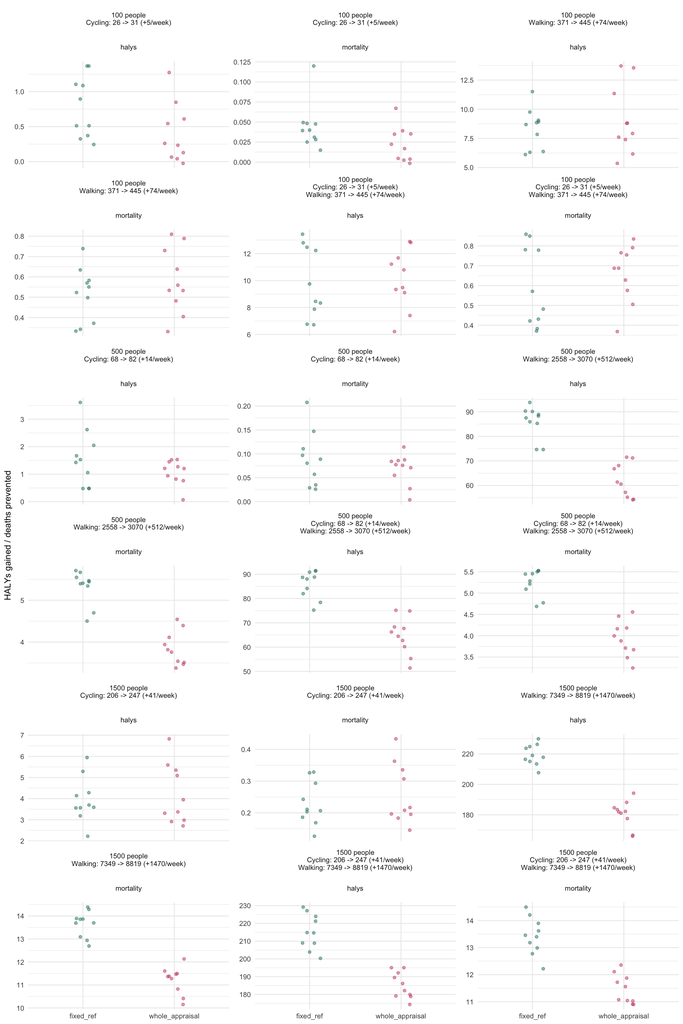

| People | Weekly trips: REF -> CF (change) | Experiment | Outcome | Draws | Mean benefit | SD of benefit | Relative SD (%) |
| --- | --- | --- | --- | --- | --- | --- | --- |
| 100 | Cycling: 26 -> 31 (+5/week) | fixed_ref | halys | 10 | 0.7791 | 0.4356 | 55.9081 |
| 100 | Cycling: 26 -> 31 (+5/week) | fixed_ref | mortality | 10 | 0.0443 | 0.0288 | 65.0190 |
| 100 | Cycling: 26 -> 31 (+5/week) | whole_appraisal | halys | 10 | 0.3979 | 0.4186 | 105.2027 |
| 100 | Cycling: 26 -> 31 (+5/week) | whole_appraisal | mortality | 10 | 0.0224 | 0.0218 | 96.9001 |
| 100 | Walking: 371 -> 445 (+74/week) | fixed_ref | halys | 10 | 8.3413 | 1.7164 | 20.5772 |
| 100 | Walking: 371 -> 445 (+74/week) | fixed_ref | mortality | 10 | 0.5144 | 0.1321 | 25.6781 |
| 100 | Walking: 371 -> 445 (+74/week) | whole_appraisal | halys | 10 | 9.0651 | 2.8942 | 31.9265 |
| 100 | Walking: 371 -> 445 (+74/week) | whole_appraisal | mortality | 10 | 0.5809 | 0.1596 | 27.4797 |
| 100 | Cycling: 26 -> 31 (+5/week); Walking: 371 -> 445 (+74/week) | fixed_ref | halys | 10 | 9.8818 | 2.6155 | 26.4680 |
| 100 | Cycling: 26 -> 31 (+5/week); Walking: 371 -> 445 (+74/week) | fixed_ref | mortality | 10 | 0.5926 | 0.2022 | 34.1265 |
| 100 | Cycling: 26 -> 31 (+5/week); Walking: 371 -> 445 (+74/week) | whole_appraisal | halys | 10 | 10.0924 | 2.2039 | 21.8376 |
| 100 | Cycling: 26 -> 31 (+5/week); Walking: 371 -> 445 (+74/week) | whole_appraisal | mortality | 10 | 0.6597 | 0.1439 | 21.8187 |
| 500 | Cycling: 68 -> 82 (+14/week) | fixed_ref | halys | 10 | 1.5399 | 1.0192 | 66.1833 |
| 500 | Cycling: 68 -> 82 (+14/week) | fixed_ref | mortality | 10 | 0.0879 | 0.0573 | 65.2245 |
| 500 | Cycling: 68 -> 82 (+14/week) | whole_appraisal | halys | 10 | 1.0784 | 0.4493 | 41.6660 |
| 500 | Cycling: 68 -> 82 (+14/week) | whole_appraisal | mortality | 10 | 0.0682 | 0.0320 | 46.9390 |
| 500 | Walking: 2558 -> 3070 (+512/week) | fixed_ref | halys | 10 | 85.9357 | 6.4216 | 7.4725 |
| 500 | Walking: 2558 -> 3070 (+512/week) | fixed_ref | mortality | 10 | 5.3185 | 0.3989 | 7.4998 |
| 500 | Walking: 2558 -> 3070 (+512/week) | whole_appraisal | halys | 10 | 62.0430 | 6.8871 | 11.1006 |
| 500 | Walking: 2558 -> 3070 (+512/week) | whole_appraisal | mortality | 10 | 3.8470 | 0.4001 | 10.3999 |
| 500 | Cycling: 68 -> 82 (+14/week); Walking: 2558 -> 3070 (+512/week) | fixed_ref | halys | 10 | 85.8943 | 5.7169 | 6.6558 |
| 500 | Cycling: 68 -> 82 (+14/week); Walking: 2558 -> 3070 (+512/week) | fixed_ref | mortality | 10 | 5.2499 | 0.3102 | 5.9083 |
| 500 | Cycling: 68 -> 82 (+14/week); Walking: 2558 -> 3070 (+512/week) | whole_appraisal | halys | 10 | 64.6240 | 7.6544 | 11.8445 |
| 500 | Cycling: 68 -> 82 (+14/week); Walking: 2558 -> 3070 (+512/week) | whole_appraisal | mortality | 10 | 3.9350 | 0.4193 | 10.6553 |
| 1500 | Cycling: 206 -> 247 (+41/week) | fixed_ref | halys | 10 | 3.9480 | 1.0530 | 26.6710 |
| 1500 | Cycling: 206 -> 247 (+41/week) | fixed_ref | mortality | 10 | 0.2291 | 0.0677 | 29.5234 |
| 1500 | Cycling: 206 -> 247 (+41/week) | whole_appraisal | halys | 10 | 4.2098 | 1.4088 | 33.4653 |
| 1500 | Cycling: 206 -> 247 (+41/week) | whole_appraisal | mortality | 10 | 0.2583 | 0.0944 | 36.5653 |
| 1500 | Walking: 7349 -> 8819 (+1470/week) | fixed_ref | halys | 10 | 219.4177 | 6.7426 | 3.0730 |
| 1500 | Walking: 7349 -> 8819 (+1470/week) | fixed_ref | mortality | 10 | 13.6402 | 0.5611 | 4.1139 |
| 1500 | Walking: 7349 -> 8819 (+1470/week) | whole_appraisal | halys | 10 | 180.5709 | 8.7643 | 4.8537 |
| 1500 | Walking: 7349 -> 8819 (+1470/week) | whole_appraisal | mortality | 10 | 11.2099 | 0.5883 | 5.2481 |
| 1500 | Cycling: 206 -> 247 (+41/week); Walking: 7349 -> 8819 (+1470/week) | fixed_ref | halys | 10 | 215.3006 | 9.8971 | 4.5969 |
| 1500 | Cycling: 206 -> 247 (+41/week); Walking: 7349 -> 8819 (+1470/week) | fixed_ref | mortality | 10 | 13.4233 | 0.6789 | 5.0579 |
| 1500 | Cycling: 206 -> 247 (+41/week); Walking: 7349 -> 8819 (+1470/week) | whole_appraisal | halys | 10 | 185.2132 | 7.4066 | 3.9989 |
| 1500 | Cycling: 206 -> 247 (+41/week); Walking: 7349 -> 8819 (+1470/week) | whole_appraisal | mortality | 10 | 11.4573 | 0.5373 | 4.6900 |

**Note**

These are fresh diagnostic runs, not the proposed final 100-replicate study. The main comparison above concerns HALYs and mortality; all disease-specific summaries remain in the generated `summary.csv` rather than being added together. `summary_with_trip_context.csv` includes the same full statistics with mode-specific trip context; `scenario_trip_inputs.csv` supplies the separate numeric trip columns.

# Diagnostics and failures

The diagnostics CSV contains changed-person counts, recipient age and baseline activity, MMET changes, donor copies and extra trip rows. Run-level RDS files retain profiles, person-level exposure, and the sampling report containing current/new users, shifted/induced trips and donor fallbacks. Failure rows are retained; successful-run summaries can be misleading if failures are systematic.

| id | status | warnings |
| --- | --- | --- |

| Generated | Commit |
| --- | --- |
| 2026-09-10 19:47:14.971588 | 7ec3f0bba423861305794433a209e479964c9584 |

# Reproduction

**Rendering the saved results does not rerun the simulation.** From `docs`:

```bash
quarto render sampling_variance_evaluation.qmd --to html
quarto render sampling_variance_evaluation.qmd --to pdf
```

Only to generate a new simulation batch, from HUB root:

```r
pkgload::load_all(".")
source("inst/workflows/dev_sampling_variance.R")
run_sampling_variance(n_replicates = 100)
```

Render from `docs`: `quarto render sampling_variance_evaluation.qmd`. Runs are fresh, never reused from the old pilot cache. The manifest saves configuration, seeds, source/code/data fingerprints and the R session. The original implementation is retained under `docs/archive/`, not used here.

# Appendix: assumptions and provenance

Defaults are resolved once per scenario with `prepare_assumption_profile()`. Every final profile and `get_appraisal_assumptions()` output is saved. Effective values and provenance must have the same signature across repetitions, or the run is recorded as an error. Card applicability may change after accepting generated counts without the underlying values changing.

| scenario | field | value | source |
| --- | --- | --- | --- |
| 100_walking | assump_induced_trips_percent | 10 | Configured preference |
| 100_walking | assump_trip_source_shares_walk | {“car”:{“percent”:81.8103},“bike”:{“percent”:2.2628},“pt”:{“percent”:15.9269}} | REF/source trip distribution |
| 100_walking | assump_trips_per_user_per_week_walk | 8.8333 | REF population |
| 100_walking | assump_trip_distance_km_walk | 1.373 | REF population |
| 100_walking | assump_trip_duration_min_walk | 18.7898 | REF population |
| 100_walking | assump_trip_speed_kmh_walk | 5 | Fixed fallback |
| 100_walking | assump_new_user_percent | 10 | Configured preference |
| 100_walking | assump_new_user_activity_pattern | “observed_donor_patterns” | Implemented sampling policy |
| 100_cycling | assump_induced_trips_percent | 10 | Configured preference |
| 100_cycling | assump_trip_source_shares_bike | {“car”:{“percent”:63.1191},“walk”:{“percent”:24.6319},“pt”:{“percent”:12.249}} | REF/source trip distribution |
| 100_cycling | assump_trips_per_user_per_week_bike | 6.5 | REF population |
| 100_cycling | assump_trip_distance_km_bike | 2.1412 | REF population |
| 100_cycling | assump_trip_duration_min_bike | 12.6923 | REF population |
| 100_cycling | assump_trip_speed_kmh_bike | 15.7 | Fixed fallback |
| 100_cycling | assump_new_user_percent | 10 | Configured preference |
| 100_cycling | assump_new_user_activity_pattern | “observed_donor_patterns” | Implemented sampling policy |
| 100_walking+cycling | assump_induced_trips_percent | 10 | Configured preference |
| 100_walking+cycling | assump_trip_source_shares_walk | {“car”:{“percent”:81.8103},“bike”:{“percent”:2.2628},“pt”:{“percent”:15.9269}} | REF/source trip distribution |
| 100_walking+cycling | assump_trips_per_user_per_week_walk | 8.8333 | REF population |
| 100_walking+cycling | assump_trip_distance_km_walk | 1.373 | REF population |
| 100_walking+cycling | assump_trip_duration_min_walk | 18.7898 | REF population |
| 100_walking+cycling | assump_trip_speed_kmh_walk | 5 | Fixed fallback |
| 100_walking+cycling | assump_new_user_percent | 10 | Configured preference |
| 100_walking+cycling | assump_new_user_activity_pattern | “observed_donor_patterns” | Implemented sampling policy |
| 100_walking+cycling | assump_trip_source_shares_bike | {“car”:{“percent”:63.1191},“walk”:{“percent”:24.6319},“pt”:{“percent”:12.249}} | REF/source trip distribution |
| 100_walking+cycling | assump_trips_per_user_per_week_bike | 6.5 | REF population |
| 100_walking+cycling | assump_trip_distance_km_bike | 2.1412 | REF population |
| 100_walking+cycling | assump_trip_duration_min_bike | 12.6923 | REF population |
| 100_walking+cycling | assump_trip_speed_kmh_bike | 15.7 | Fixed fallback |
| 500_walking | assump_induced_trips_percent | 10 | Configured preference |

[output cut: 57 more lines]